# Missing values - Matan Shemesh

#### קריאת הקובץ החדש לאחר הטיפול בערכי קיצון

```python
import pandas as pd
import numpy as np
import matplotlib.pyplot as plt
from matplotlib import rcParams
from matplotlib.backends.backend_pdf import PdfPages
import seaborn as sns
from scipy import stats
from scipy.stats import spearmanr
import matplotlib.pyplot as plt
from scipy.stats import norm
from scipy.stats import chi2_contingency
from scipy.stats import chi2
from sklearn.impute import KNNImputer

df = pd.read_csv("D:/מבוא למדעי הנתונים/מטלה 1/df_removed_outliers.csv")
df.head()
```

|  | Unnamed: 0 | age | sex | marital_status | ses | residence | weigh | heigh | BMI | bp_sys | ... | Charlson | framingham_cvd | antidiabetics | ERD | CVD | HTN | cardiovascular_meds | statines | immigrant | dead_5y |
| --- | --- | --- | --- | --- | --- | --- | --- | --- | --- | --- | --- | --- | --- | --- | --- | --- | --- | --- | --- | --- | --- |
| 0 | 0 | 49.0 | 2 | U | 1 | urban | 84.0 | 160.0 | 32.79 | 116.0 | ... | 1 | 0.12908 | 1 | 0 | 0 | 1 | 1 | 1 | 0 | 0 |
| 1 | 1 | 46.0 | 2 | M | 1 | urban | 67.0 | 152.0 | 29.38 | 113.0 | ... | 1 | 0.08500 | 1 | 0 | 0 | 0 | 1 | 1 | 0 | 0 |
| 2 | 2 | 46.0 | 2 | U | 1 | urban | 62.4 | 148.0 | 28.31 | 133.0 | ... | 1 | 0.10715 | 1 | 0 | 0 | 1 | 1 | 1 | 0 | 0 |
| 3 | 3 | 45.0 | 1 | U | 2 | urban | 73.9 | 166.0 | 26.85 | NaN | ... | 1 | 0.10110 | 1 | 0 | 0 | 0 | 0 | 1 | 0 | 0 |
| 4 | 4 | 49.0 | 2 | U | 1 | urban | 53.0 | 161.0 | 20.45 | 110.0 | ... | 1 | 0.03950 | 1 | 0 | 0 | 0 | 0 | 1 | 0 | 0 |

5 rows × 43 columns

```python
# מוחק את שורת האינדקסים שהתווספה
df.drop(['Unnamed: 0'], axis = 1, inplace=True)
```

```python
num_vars = ['age','weigh','heigh','BMI','bp_sys','bp_dias','HbA1c','glucose','creatinin','albumin','alb24h','ACR','cholesterol_total','LDL','HDL','triglycerides','TSH','gravity_u','WBC','RBC','platelets','MCV','MPV','framingham_cvd']
cat_vars = [col for col in df.columns if col not in num_vars]
#change the categorical variables to categoy type
for column in df[cat_vars]:
    df[column] = df[column].astype('category')
```

#### בודק את החסרים בצורה רחבה: מייצר מטריצת חסרים ובודק אותה עם מפת חום

#### חישוב אחוז החסרים בכל משתנה

```python
df.isna().sum()/df.shape[0]*100
```

```
age                     0.699469
sex                     0.000000
marital_status          0.000000
ses                     0.000000
residence               0.000000
weigh                   2.042129
heigh                   0.192957
BMI                     2.026049
bp_sys                  9.768452
bp_dias                 4.212896
bp_cat                  0.000000
smoking_status          0.000000
HbA1c                   4.092298
glucose                 6.110307
creatinin               1.969770
albumin                13.145200
alb24h                 71.699630
ACR                    23.130728
cholesterol_total       1.704454
LDL                     1.374819
HDL                     2.420003
triglycerides           5.282200
TSH                     4.494292
gravity_u              21.080560
nitrites_u             20.260492
leuko_u                20.155974
proteinuria            20.147934
WBC                     1.977810
RBC                     1.543657
platelets               2.299405
MCV                     4.566651
MPV                     2.387844
Charlson                0.000000
framingham_cvd          4.888246
antidiabetics           0.000000
ERD                     0.000000
CVD                     0.000000
HTN                     0.000000
cardiovascular_meds     0.000000
statines                0.000000
immigrant               0.000000
dead_5y                 0.000000
dtype: float64
```

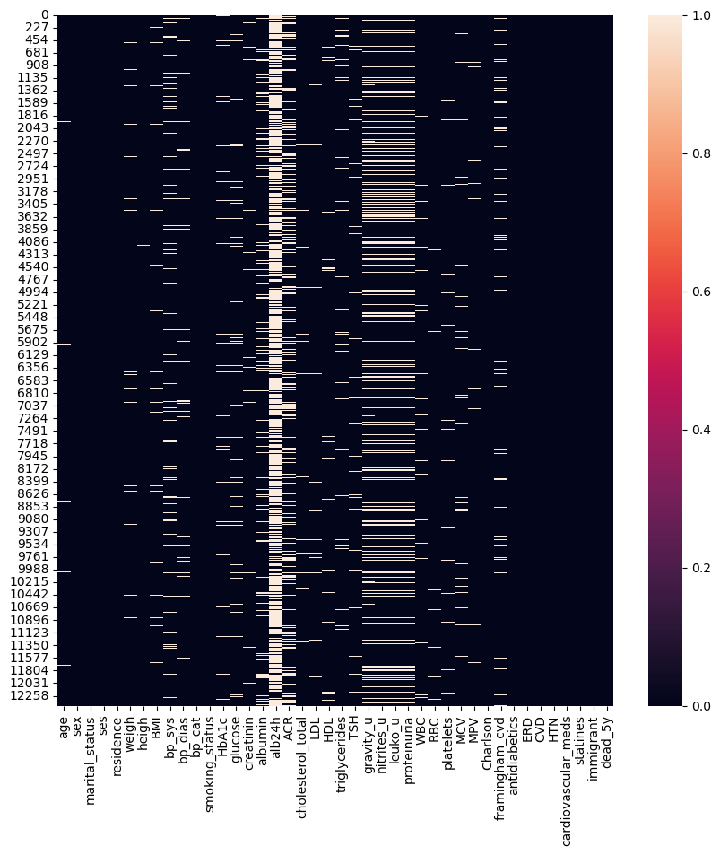

```python
#createing a missing values matrix
missing_mat = np.array(df.isnull()).astype(int)

#creating heatmap of missing values
plt.figure(figsize=(10,10))
sns.heatmap(df.isnull())
```

#### .אנחנו רואים שלמשתנה איסוף חלבון בשתן במשך 24 שעות יש יותר מ70% חסרים

#### .למשתנים בדיקת משקל הסגולי בשתן, ניטריטים בשתן, כדוריות לבנות בשתן, יחס בין אלבומין לקראטיניו וחלבון בשתן יש כ- 20% חסרים

### טיפול בחסרים

#### :בדיקת חסרים בשורות

#### אם יש יותר מ-50% חסרים באותה שורה, מוחקים את השורה

```python
#deleting rows that have more than 50% missing values

missing_prop_by_row = df.isnull().sum(axis = 1).sort_values(ascending=False)/df.shape[1]
rows_to_drop = missing_prop_by_row[missing_prop_by_row >= 0.5].index
print("The rows that need to be deleted:", rows_to_drop.values)
df.drop(rows_to_drop, axis = 0, inplace=True)
```

```
The rows that need to be deleted: []
```

#### אנחנו רואים שאין שורות שיש בהם יותר מ- 50% חסרים

#### :כעת נבצע בדיקות על העמודות

#### בעמודות שיש 70% או יותר חסרים, צריך למחוק

```python
#deleting cols that have more than 70% missing values
missing_prop_by_col = df.isnull().sum(axis = 0).sort_values(ascending=False)/df.shape[0]
cols_to_drop = missing_prop_by_col[missing_prop_by_col >= 0.7].index
print("The percentage of missing in each column:")
print()
print(missing_prop_by_col)
print()
print("The rows that need to be deleted:", cols_to_drop.values)
df.drop(cols_to_drop, axis = 1, inplace=True)
```

```
The percentage of missing in each column:

alb24h                 0.716996
ACR                    0.231307
gravity_u              0.210806
nitrites_u             0.202605
leuko_u                0.201560
proteinuria            0.201479
albumin                0.131452
bp_sys                 0.097685
glucose                0.061103
triglycerides          0.052822
framingham_cvd         0.048882
MCV                    0.045667
TSH                    0.044943
bp_dias                0.042129
HbA1c                  0.040923
HDL                    0.024200
MPV                    0.023878
platelets              0.022994
weigh                  0.020421
BMI                    0.020260
WBC                    0.019778
creatinin              0.019698
cholesterol_total      0.017045
RBC                    0.015437
LDL                    0.013748
age                    0.006995
heigh                  0.001930
sex                    0.000000
smoking_status         0.000000
bp_cat                 0.000000
residence              0.000000
ses                    0.000000
Charlson               0.000000
marital_status         0.000000
antidiabetics          0.000000
ERD                    0.000000
CVD                    0.000000
HTN                    0.000000
cardiovascular_meds    0.000000
statines               0.000000
immigrant              0.000000
dead_5y                0.000000
dtype: float64

The rows that need to be deleted: ['alb24h']
```

#### אנחנו רואים שלמשתנה "איסוף חלבון בשתן במשך 24 שעות" יש יותר מ 70% חסרים ולכן מחקנו אותו

#### נסיר את המשתנה גם מרשימת המשתנים הנומריים

```python
num_vars.remove('alb24h')
```

#### כעת נבדוק שבאמת ירדה עמודה מהדאטה פריים

```python
df.shape
```

```
(12438, 41)
```

#### בעמודות שחסרים בין 70%-40% ,אי אפשר לעשות אמפוטציה, הופכים את המשתנה לקטגוריאלי

```python
#converting variables with 40%-70% missing values to categorical variables

missing_prop_by_col = df.isnull().sum(axis = 0).sort_values(ascending=False)/df.shape[0]
cols_to_categorize = missing_prop_by_col[missing_prop_by_col >= 0.4].index
print("The variables that need to be convert to categories:", cols_to_categorize.values)
```

```
The variables that need to be convert to categories: []
```

#### אין משתנים שאחוז החסרים שלהם הוא בין 40-70

#### .כעת נבדוק את מנגנון יצירת החסרים שמתחת ל40 אחוז. לוקחים את החיווי של המשתנה החסר (חסר/לא חסר) וכל משתנה רציף ובודקים האם יש שוני מובהק

#### (אם יש שוני מובהק, המשתנה מסביר את החוסר ולכן מספיק אחד שכן מובהק כדי להגיד שהמנגנון הוא ערכים חסרים באופן לא אקראי (חסרים כי יש סיבה הגיונית לחוסר

#### Kolmogorov smirnov במשתנים רציפים משתמשים ב

#### chi square במשתנים קטגוריאליים משתמשים ב

```python
# checking the missing mechanism for variables with under 40% missing

missing_prop_by_col = df.isnull().sum(axis = 0).sort_values(ascending=False)/df.shape[0]
#check only variables that have missing values
cols_to_check_mechanism = missing_prop_by_col[missing_prop_by_col > 0].index
vars_with_missing_values = cols_to_check_mechanism.values

p_values = {}

for col_missing in cols_to_check_mechanism:
    p_values[col_missing] = {}
    for col in df.columns:
        if col_missing != col:
            s1 = df[col]
            s2 = s1[df[col_missing].isnull() == False]
            if col_missing in cat_vars and col in cat_vars:
                 ct = pd.crosstab(s1, s2)
                 _, p, _, _ = stats.chi2_contingency(ct)
            else:
                _, p = stats.kstest(s1,s2)
            p_values[col_missing][col] = p

p_values_df = pd.DataFrame(p_values)
p_values_df
```

|  | ACR | gravity_u | nitrites_u | leuko_u | proteinuria | albumin | bp_sys | glucose | triglycerides | framingham_cvd | ... | platelets | weigh | BMI | WBC | creatinin | cholesterol_total | RBC | LDL | age | heigh |
| --- | --- | --- | --- | --- | --- | --- | --- | --- | --- | --- | --- | --- | --- | --- | --- | --- | --- | --- | --- | --- | --- |
| age | 0.507158 | 9.505785e-01 | 8.392836e-01 | 7.924034e-01 | 7.849058e-01 | 0.998594 | 9.898532e-01 | 9.990296e-01 | 1.000000 | 0.129417 | ... | 1.000000 | 1.000000 | 1.000000 | 1.000000 | 1.000000 | 1.000000 | 1.000000 | 1.000000 | NaN | 1.0 |
| sex | 1.000000 | 1.764785e-03 | 0.000000e+00 | 0.000000e+00 | 0.000000e+00 | 0.982800 | 9.999913e-01 | 9.991899e-01 | 0.740628 | 0.004277 | ... | 0.844480 | 0.999854 | 0.997156 | 1.000000 | 0.973353 | 1.000000 | 0.999987 | 1.000000 | 1.0 | 1.0 |
| marital_status | 0.919361 | 1.000000e+00 | 0.000000e+00 | 0.000000e+00 | 0.000000e+00 | 1.000000 | 9.999966e-01 | 1.000000e+00 | 1.000000 | 1.000000 | ... | 1.000000 | 1.000000 | 1.000000 | 1.000000 | 1.000000 | 1.000000 | 1.000000 | 1.000000 | 1.0 | 1.0 |
| ses | 0.998910 | 9.999986e-01 | 0.000000e+00 | 0.000000e+00 | 0.000000e+00 | 1.000000 | 9.999515e-01 | 9.989334e-01 | 1.000000 | 1.000000 | ... | 1.000000 | 1.000000 | 1.000000 | 1.000000 | 1.000000 | 1.000000 | 1.000000 | 1.000000 | 1.0 | 1.0 |
| residence | 1.000000 | 1.000000e+00 | 0.000000e+00 | 0.000000e+00 | 0.000000e+00 | 1.000000 | 1.000000e+00 | 1.000000e+00 | 1.000000 | 1.000000 | ... | 1.000000 | 1.000000 | 1.000000 | 1.000000 | 1.000000 | 1.000000 | 1.000000 | 1.000000 | 1.0 | 1.0 |
| weigh | 0.080229 | 1.000000e+00 | 9.999997e-01 | 9.999983e-01 | 9.999974e-01 | 0.969407 | 9.990282e-01 | 9.999999e-01 | 0.934105 | 0.986303 | ... | 1.000000 | NaN | 0.053372 | 1.000000 | 1.000000 | 1.000000 | 1.000000 | 1.000000 | 1.0 | 1.0 |
| heigh | 0.997599 | 3.336442e-02 | 3.750079e-02 | 3.994623e-02 | 3.912631e-02 | 0.999992 | 9.366224e-01 | 1.000000e+00 | 0.949509 | 0.073013 | ... | 0.979522 | 0.942019 | 0.998989 | 1.000000 | 0.999794 | 1.000000 | 0.999999 | 1.000000 | 1.0 | NaN |
| BMI | 0.018548 | 4.513816e-01 | 5.773315e-01 | 6.375156e-01 | 6.431775e-01 | 0.728105 | 8.417825e-01 | 1.000000e+00 | 0.999915 | 1.000000 | ... | 1.000000 | 0.039345 | NaN | 1.000000 | 1.000000 | 1.000000 | 1.000000 | 1.000000 | 1.0 | 1.0 |
| bp_sys | 0.000642 | 9.971494e-01 | 9.984752e-01 | 9.950876e-01 | 9.945934e-01 | 0.999999 | NaN | 9.830118e-01 | 0.998864 | 0.216242 | ... | 1.000000 | 0.996067 | 0.999891 | 1.000000 | 1.000000 | 1.000000 | 1.000000 | 1.000000 | 1.0 | 1.0 |
| bp_dias | 0.004616 | 9.999999e-01 | 9.999367e-01 | 9.998710e-01 | 9.998265e-01 | 1.000000 | 4.416005e-06 | 9.944359e-01 | 0.979881 | 0.775679 | ... | 1.000000 | 1.000000 | 1.000000 | 1.000000 | 1.000000 | 1.000000 | 1.000000 | 1.000000 | 1.0 | 1.0 |
| bp_cat | 0.049342 | 1.000000e+00 | 0.000000e+00 | 0.000000e+00 | 0.000000e+00 | 1.000000 | 1.999261e-12 | 1.000000e+00 | 0.999982 | 0.592840 | ... | 1.000000 | 0.999998 | 1.000000 | 1.000000 | 1.000000 | 1.000000 | 1.000000 | 1.000000 | 1.0 | 1.0 |
| smoking_status | 0.874660 | 4.021302e-01 | 0.000000e+00 | 0.000000e+00 | 0.000000e+00 | 1.000000 | 1.000000e+00 | 9.999967e-01 | 0.975340 | 0.000004 | ... | 1.000000 | 1.000000 | 1.000000 | 0.986596 | 1.000000 | 1.000000 | 1.000000 | 1.000000 | 1.0 | 1.0 |
| HbA1c | 0.003319 | 4.693252e-01 | 8.251460e-01 | 7.697018e-01 | 7.771883e-01 | 0.950199 | 9.552446e-01 | 5.336893e-12 | 0.381794 | 0.788155 | ... | 1.000000 | 1.000000 | 1.000000 | 1.000000 | 1.000000 | 0.999139 | 1.000000 | 0.999998 | 1.0 | 1.0 |
| glucose | 0.015772 | 2.413754e-01 | 5.332949e-01 | 4.795056e-01 | 4.870742e-01 | 1.000000 | 9.495361e-01 | NaN | 0.183674 | 0.863603 | ... | 1.000000 | 1.000000 | 1.000000 | 1.000000 | 0.999995 | 0.990317 | 1.000000 | 1.000000 | 1.0 | 1.0 |
| creatinin | 0.736491 | 2.147762e-01 | 1.690290e-01 | 1.823923e-01 | 1.789168e-01 | 0.956166 | 1.000000e+00 | 1.000000e+00 | 0.990058 | 0.260310 | ... | 0.997738 | 1.000000 | 0.999996 | 1.000000 | NaN | 1.000000 | 1.000000 | 1.000000 | 1.0 | 1.0 |
| albumin | 0.263037 | 7.566420e-02 | 1.015144e-01 | 1.078277e-01 | 1.068471e-01 | NaN | 9.958139e-01 | 9.802906e-01 | 1.000000 | 0.999850 | ... | 0.999642 | 1.000000 | 0.981145 | 1.000000 | 1.000000 | 1.000000 | 1.000000 | 1.000000 | 1.0 | 1.0 |
| cholesterol_total | 0.000643 | 5.487324e-01 | 6.206359e-01 | 6.505743e-01 | 6.432038e-01 | 1.000000 | 9.999345e-01 | 2.090008e-01 | 0.006579 | 0.139042 | ... | 1.000000 | 1.000000 | 1.000000 | 1.000000 | 1.000000 | NaN | 1.000000 | 0.325235 | 1.0 | 1.0 |
| LDL | 0.160094 | 6.884318e-01 | 7.744225e-01 | 8.237686e-01 | 8.194049e-01 | 1.000000 | 1.000000e+00 | 6.178433e-01 | 0.999942 | 0.672396 | ... | 1.000000 | 1.000000 | 1.000000 | 1.000000 | 1.000000 | 0.578220 | 1.000000 | NaN | 1.0 | 1.0 |
| HDL | 0.999505 | 9.457237e-01 | 9.511727e-01 | 9.462034e-01 | 9.443920e-01 | 1.000000 | 9.999995e-01 | 1.000000e+00 | 0.046469 | 0.265513 | ... | 1.000000 | 0.999965 | 1.000000 | 1.000000 | 1.000000 | 1.000000 | 1.000000 | 1.000000 | 1.0 | 1.0 |
| triglycerides | 0.014817 | 8.157330e-01 | 8.808671e-01 | 8.868679e-01 | 8.806114e-01 | 1.000000 | 9.999680e-01 | 3.820454e-01 | NaN | 0.016511 | ... | 1.000000 | 1.000000 | 1.000000 | 0.999573 | 1.000000 | 0.671394 | 1.000000 | 1.000000 | 1.0 | 1.0 |
| TSH | 0.127871 | 9.593969e-01 | 9.614810e-01 | 9.778115e-01 | 9.804373e-01 | 0.999999 | 9.999988e-01 | 1.000000e+00 | 1.000000 | 0.996519 | ... | 0.999762 | 1.000000 | 0.994900 | 1.000000 | 0.936844 | 1.000000 | 0.998216 | 1.000000 | 1.0 | 1.0 |
| gravity_u | 0.475089 | NaN | 5.951289e-195 | 1.457199e-192 | 2.275872e-192 | 0.094290 | 9.999999e-01 | 6.696983e-01 | 1.000000 | 1.000000 | ... | 1.000000 | 1.000000 | 1.000000 | 1.000000 | 1.000000 | 1.000000 | 1.000000 | 1.000000 | 1.0 | 1.0 |
| nitrites_u | 0.554425 | 6.678621e-198 | NaN | 0.000000e+00 | 0.000000e+00 | 0.185417 | 1.000000e+00 | 9.979648e-01 | 1.000000 | 1.000000 | ... | 1.000000 | 1.000000 | 1.000000 | 1.000000 | 1.000000 | 1.000000 | 1.000000 | 1.000000 | 1.0 | 1.0 |
| leuko_u | 0.351846 | 7.509072e-196 | 0.000000e+00 | NaN | 0.000000e+00 | 0.222982 | 9.960544e-01 | 9.997009e-01 | 1.000000 | 1.000000 | ... | 1.000000 | 1.000000 | 1.000000 | 1.000000 | 1.000000 | 1.000000 | 1.000000 | 1.000000 | 1.0 | 1.0 |
| proteinuria | 0.000055 | 1.078678e-195 | 0.000000e+00 | 0.000000e+00 | NaN | 0.198671 | 9.973028e-01 | 9.953697e-01 | 0.999999 | 0.999978 | ... | 1.000000 | 1.000000 | 1.000000 | 1.000000 | 0.801579 | 1.000000 | 1.000000 | 1.000000 | 1.0 | 1.0 |
| WBC | 0.167047 | 1.000000e+00 | 1.000000e+00 | 1.000000e+00 | 1.000000e+00 | 0.999987 | 9.999964e-01 | 1.000000e+00 | 0.948223 | 0.605142 | ... | 0.985620 | 1.000000 | 1.000000 | NaN | 1.000000 | 1.000000 | 1.000000 | 1.000000 | 1.0 | 1.0 |
| RBC | 0.431115 | 2.449993e-01 | 3.592591e-01 | 4.162944e-01 | 4.209230e-01 | 0.995686 | 1.000000e+00 | 2.575439e-01 | 0.736520 | 0.256522 | ... | 0.997672 | 1.000000 | 1.000000 | 1.000000 | 1.000000 | 1.000000 | NaN | 1.000000 | 1.0 | 1.0 |
| platelets | 0.983726 | 8.610226e-01 | 8.270773e-01 | 7.938946e-01 | 7.998115e-01 | 1.000000 | 9.999986e-01 | 9.999994e-01 | 1.000000 | 0.999983 | ... | NaN | 1.000000 | 1.000000 | 0.966311 | 1.000000 | 1.000000 | 1.000000 | 1.000000 | 1.0 | 1.0 |
| MCV | 0.751402 | 9.909085e-01 | 9.867412e-01 | 9.811557e-01 | 9.823263e-01 | 1.000000 | 1.000000e+00 | 9.996804e-01 | 1.000000 | 0.878843 | ... | 1.000000 | 1.000000 | 1.000000 | 1.000000 | 1.000000 | 1.000000 | 0.907717 | 1.000000 | 1.0 | 1.0 |
| MPV | 0.995182 | 9.992541e-01 | 9.978374e-01 | 9.995295e-01 | 9.994662e-01 | 0.999359 | 1.000000e+00 | 9.942838e-01 | 1.000000 | 0.999877 | ... | 0.994227 | 1.000000 | 1.000000 | 1.000000 | 1.000000 | 1.000000 | 1.000000 | 1.000000 | 1.0 | 1.0 |
| Charlson | 0.014159 | 9.847126e-01 | 0.000000e+00 | 0.000000e+00 | 0.000000e+00 | 1.000000 | 9.989606e-01 | 1.000000e+00 | 0.999842 | 0.998427 | ... | 1.000000 | 1.000000 | 1.000000 | 1.000000 | 0.628153 | 1.000000 | 1.000000 | 1.000000 | 1.0 | 1.0 |
| framingham_cvd | 0.203331 | 2.380645e-02 | 2.389756e-02 | 2.443950e-02 | 2.390824e-02 | 0.999989 | 7.037896e-02 | 7.559021e-01 | 0.093589 | NaN | ... | 0.999988 | 1.000000 | 1.000000 | 1.000000 | 0.999893 | 0.980650 | 1.000000 | 0.999136 | 1.0 | 1.0 |
| antidiabetics | 0.288200 | 1.000000e+00 | 0.000000e+00 | 0.000000e+00 | 0.000000e+00 | 1.000000 | 1.000000e+00 | 9.430459e-01 | 1.000000 | 1.000000 | ... | 1.000000 | 1.000000 | 1.000000 | 1.000000 | 1.000000 | 1.000000 | 1.000000 | 1.000000 | 1.0 | 1.0 |
| ERD | 1.000000 | 1.000000e+00 | 0.000000e+00 | 0.000000e+00 | 0.000000e+00 | 1.000000 | 1.000000e+00 | 1.000000e+00 | 1.000000 | 1.000000 | ... | 1.000000 | 1.000000 | 1.000000 | 1.000000 | 0.999972 | 1.000000 | 1.000000 | 1.000000 | 1.0 | 1.0 |
| CVD | 0.956491 | 1.000000e+00 | 0.000000e+00 | 0.000000e+00 | 0.000000e+00 | 1.000000 | 9.964132e-01 | 1.000000e+00 | 0.999998 | 0.924193 | ... | 1.000000 | 1.000000 | 1.000000 | 1.000000 | 1.000000 | 1.000000 | 1.000000 | 1.000000 | 1.0 | 1.0 |
| HTN | 0.039349 | 1.000000e+00 | 0.000000e+00 | 0.000000e+00 | 0.000000e+00 | 1.000000 | 2.502588e-01 | 9.999991e-01 | 0.999995 | 0.933106 | ... | 1.000000 | 0.999846 | 1.000000 | 1.000000 | 1.000000 | 1.000000 | 1.000000 | 1.000000 | 1.0 | 1.0 |
| cardiovascular_meds | 0.000617 | 1.000000e+00 | 0.000000e+00 | 0.000000e+00 | 0.000000e+00 | 1.000000 | 4.876407e-01 | 1.000000e+00 | 1.000000 | 0.790523 | ... | 1.000000 | 0.999999 | 1.000000 | 1.000000 | 1.000000 | 1.000000 | 1.000000 | 1.000000 | 1.0 | 1.0 |
| statines | 1.000000 | 1.000000e+00 | 0.000000e+00 | 0.000000e+00 | 0.000000e+00 | 1.000000 | 1.000000e+00 | 1.000000e+00 | 0.999701 | 0.879359 | ... | 1.000000 | 1.000000 | 1.000000 | 1.000000 | 1.000000 | 1.000000 | 1.000000 | 1.000000 | 1.0 | 1.0 |
| immigrant | 0.998352 | 1.000000e+00 | 0.000000e+00 | 0.000000e+00 | 0.000000e+00 | 0.998926 | 1.000000e+00 | 1.000000e+00 | 1.000000 | 1.000000 | ... | 1.000000 | 1.000000 | 1.000000 | 1.000000 | 1.000000 | 1.000000 | 1.000000 | 1.000000 | 1.0 | 1.0 |
| dead_5y | 1.000000 | 1.000000e+00 | 0.000000e+00 | 0.000000e+00 | 0.000000e+00 | 1.000000 | 1.000000e+00 | 1.000000e+00 | 1.000000 | 1.000000 | ... | 1.000000 | 1.000000 | 1.000000 | 1.000000 | 1.000000 | 1.000000 | 1.000000 | 1.000000 | 1.0 | 1.0 |
| ACR | NaN | 6.793108e-01 | 6.284058e-01 | 6.025371e-01 | 5.996295e-01 | 1.000000 | 5.218762e-01 | 2.075518e-01 | 0.686460 | 0.981809 | ... | 1.000000 | 0.998207 | 0.999892 | 1.000000 | 0.920989 | 1.000000 | 1.000000 | 1.000000 | 1.0 | 1.0 |

41 rows × 26 columns

#### MNAR - missing not at random

#### יוצר רשימה של המשתנים שהיה להם לפחות שוני אחד מובהק כדי שנדע להפוך אותם לקטגוריאליים בהמשך

```python
def MNAR(df, val):
    out_list = [df_col for df_col in df.columns if True in (df[df_col]<val).tolist()]
    return out_list

change_to_category = MNAR(p_values_df, 0.05)
change_to_category
```

```
['ACR',
 'gravity_u',
 'nitrites_u',
 'leuko_u',
 'proteinuria',
 'bp_sys',
 'glucose',
 'triglycerides',
 'framingham_cvd',
 'MCV',
 'bp_dias',
 'HbA1c',
 'weigh']
```

#### יוצר רשימה של המשתנים שאפשרי לעשות להם אימפוטציה

```python
vars_to_impute = [var for var in vars_with_missing_values if var not in change_to_category]
vars_to_impute
```

```
['albumin',
 'TSH',
 'HDL',
 'MPV',
 'platelets',
 'BMI',
 'WBC',
 'creatinin',
 'cholesterol_total',
 'RBC',
 'LDL',
 'age',
 'heigh']
```

#### ".כאשר אי אפשר לעשות אימפוטציה הופכים לקטגוריאלי: השתמשתי בטווח בין רבעוני כדי לחלק לקטגוריות. את הערכים החסרים הכנסתי לקטגוריה שנקראת "לא ידוע

#### "אני יוצר פונקציה שעושה חילוק בין המשתנים הקטגוריאליים לנומריים: לקטגוריאליים היא מוסיפה את הערכים החסרים לקטגוריה של "לא ידוע

#### ."את המשתנים הנומריים היא מחלקת ל-5 קטגוריות, עד 25%, עד 50%, עד 75%, עד 100% ו-"לא ידוע

#### .לאחר מכן אני קורא לפונקציה עם המשתנים שאי אפשר לעשות להם אימפוטציה

```python
def convert_var_to_categorial(df, var):

    if df[var].dtype.name == 'category':
        df[var] = df[var].cat.add_categories('unknown')
        for i, val in enumerate(df[var]):
            if np.isnan(val):
                df.loc[i, var] = 'unknown'
    else:
        s = df[var]
        converted_to_cat = []

        for i, val in enumerate(df[var]):
            if np.isnan(val):
                converted_to_cat.append('unknown')
            elif val < s.quantile(0.25):
                converted_to_cat.append(1)
            elif val < s.quantile(0.5):
                converted_to_cat.append(2)
            elif val < s.quantile(0.75):
                converted_to_cat.append(3)
            else:
                converted_to_cat.append(4)
        #change the type of varibales to catgory and replace them to categorial vars
        var_to_cat = pd.Series(converted_to_cat, dtype='category')
        df[var] = var_to_cat
        # add the variable to categorial vars
        cat_vars.append(var)
        #remove the variable from numerical vars
        num_vars.remove(var)
    return df
```

```python
for var in change_to_category:
    df = convert_var_to_categorial(df, var)
```

```python
# check the function
df.ACR.unique()
```

```
[3, 2, 1, 4, 'unknown']
Categories (5, object): [1, 2, 3, 4, 'unknown']
```

#### .בודק שאכן אין ערכים חסרים במשתנים שהפכתי אותם לקטגוריאליים

```python
df[change_to_category].isna().sum()
```

```
ACR               0
gravity_u         0
nitrites_u        0
leuko_u           0
proteinuria       0
bp_sys            0
glucose           0
triglycerides     0
framingham_cvd    0
MCV               0
bp_dias           0
HbA1c             0
weigh             0
dtype: int64
```

#### .בודק שהמשתנים שהפכתי לקטגוריאליים אכן נוספו למשתנים הקטגוריאליים

```python
cat_vars
```

```
['sex',
 'marital_status',
 'ses',
 'residence',
 'bp_cat',
 'smoking_status',
 'nitrites_u',
 'leuko_u',
 'proteinuria',
 'Charlson',
 'antidiabetics',
 'ERD',
 'CVD',
 'HTN',
 'cardiovascular_meds',
 'statines',
 'immigrant',
 'dead_5y',
 'ACR',
 'gravity_u',
 'bp_sys',
 'glucose',
 'triglycerides',
 'framingham_cvd',
 'MCV',
 'bp_dias',
 'HbA1c',
 'weigh']
```

#### .בודק שהמשתנים שהפכתי לקטגוריאליים אכן הוסרו מהמשתנים הנומריים

```python
num_vars
```

```
['age',
 'heigh',
 'BMI',
 'creatinin',
 'albumin',
 'cholesterol_total',
 'LDL',
 'HDL',
 'TSH',
 'WBC',
 'RBC',
 'platelets',
 'MPV']
```

#### :כעת אני מטפל במשתנים שניתן לעשות להם אימפוטציה

#### KNN-Imputer עושה אימפוטציה ע"י שימוש ב

#### ומחליף את המשתנה עם הערכים שמתקבלים מהמודל

```python
imputer = KNNImputer(n_neighbors=3)
for var in vars_to_impute:
    imputed_var = imputer.fit_transform(df[var].values.reshape(-1,1))
    df[var] = imputed_var
```

#### בודק שאכן אין ערכים חסרים במשתנים שעשיתי להם אימפוטציה

```python
df[vars_to_impute].isna().sum()
```

```
albumin              0
TSH                  0
HDL                  0
MPV                  0
platelets            0
BMI                  0
WBC                  0
creatinin            0
cholesterol_total    0
RBC                  0
LDL                  0
age                  0
heigh                0
dtype: int64
```

#### בודק שאין יותר ערכים חסרים בדאטה פריים

```python
df.isna().sum()
```

```
age                    0
sex                    0
marital_status         0
ses                    0
residence              0
weigh                  0
heigh                  0
BMI                    0
bp_sys                 0
bp_dias                0
bp_cat                 0
smoking_status         0
HbA1c                  0
glucose                0
creatinin              0
albumin                0
ACR                    0
cholesterol_total      0
LDL                    0
HDL                    0
triglycerides          0
TSH                    0
gravity_u              0
nitrites_u             0
leuko_u                0
proteinuria            0
WBC                    0
RBC                    0
platelets              0
MCV                    0
MPV                    0
Charlson               0
framingham_cvd         0
antidiabetics          0
ERD                    0
CVD                    0
HTN                    0
cardiovascular_meds    0
statines               0
immigrant              0
dead_5y                0
dtype: int64
```

```python
len(num_vars), len(cat_vars)
```

```
(13, 28)
```

#### שומר את הדאטה פריים לאחר השינויים

```python
df.to_csv("D:/מבוא למדעי הנתונים/מטלה 1/df_after_missing_values_treatment.csv")
```